# What is going on with crime in Phoenix?

14 February, 2024

What do you think? Is crime on the rise? Is crime declining? Having a hard time answering that question (**and** *being confident about your answer*)? Well, you should! I certainly do (and [I am a criminologist](https://jacobtnyoung.github.io/)). But, so are most people. [Gallup polling](https://news.gallup.com/poll/268283/describe-problem-crime-serious.aspx) has consistently shown that individuals’ perceptions of crime does not (REPEAT **does not**) track trends in crime.

As I discuss in a [different post](https://jacobtnyoung.github.io/R2PhX/projects/PHXcrime.html), crime trends are **very** difficult to assess, without seeing the data, because of the peculiar nature of crime and the huge delay in reporting of crime (because of the way it is collected).

If we want to know what is going on with crime in Phoenix, we can take a look at the [Crime Data](https://www.phoenixopendata.com/dataset/crime-data) from the [data portal](https://www.phoenixopendata.com/). This file contains incidents reported to the Phoenix Police Department. The city updates the file at 11am every day and it contains data beginning November 2015 up to 7 days before the posting date.

# To the data!

First things first. We want to get the data loaded, wrangled, and ready for examining. If you want to skip that, feel free! If you want to see “how we get there”, just click the “Show” button on the right.

```r
# clear workspace
rm( list = ls() )


# load libraries
library( dplyr )    # used for wrangling the data
library( tidyr )    # used for wrangling the data
library( ggplot2 )  # for plotting
library( scales )   # for formatting the text
library( forecast ) # for working with time series data
library( openxlsx ) # for opening an excel file
library( here )     # for referencing the local directory


# ---------------
# Get the data

# The file is available at this url:
#url <- "https://www.phoenixopendata.com/dataset/cc08aace-9ca9-467f-b6c1-f0879ab1a358/resource/0ce3411a-2fc6-4302-a33f-167f68608a20/download/crime-data_crime-data_crimestat.csv"

# However, for this page I use a copy that is downloaded already
loc <- "data/data-raw/crime-data_crime-data_crimestat.csv"
crime.data <- read.csv( here( loc ), as.is = TRUE, header = TRUE )
crime.data <- na.omit( crime.data )


# Help with formatting the text
n.cases <- dim( crime.data )[1]


# Clean up the dates
date.vec <- strptime( crime.data$OCCURRED.ON, format="%m/%d/%Y %H:%M" )
crime.data$year   <- format( date.vec, format="%Y" )
crime.data$month  <- format( date.vec, format="%B" )
crime.data$day365 <- format( date.vec, format="%j" )
crime.data$week   <- format( date.vec, format="%V" )

# Drop cases for the most recent month
crime.data <- crime.data[ ! (
  crime.data$month == format( Sys.Date(), format="%B" ) &
    crime.data$year == format( Sys.Date(), format="%Y" )
) , ]


# ------------
# Use dplyr() to create an object that is the daily count of crimes
crimes.by.day <-
  crime.data %>%
  select( year, month, day365 ) %>%
  filter( !is.na( day365 ) ) %>%
  group_by( year, month, day365 ) %>%
  summarize( counts = n() ) %>%
  ungroup() %>%
  mutate( day.time = seq( 1, length( counts ) ) ) %>%
  select( counts, day.time ) %>%
  mutate( days =
            seq(
              as.Date( head( strptime( crime.data$OCCURRED.ON, format="%m/%d/%Y %H:%M" ) ) )[1],
              as.Date( tail( strptime( crime.data$OCCURRED.ON, format="%m/%d/%Y %H:%M" ) ) )[6],
              length.out = length( counts ) ) ) %>%
  arrange( day.time )

crimes.by.day <- as.data.frame( crimes.by.day )
```

## Daily trend

Let’s pull the most recent data for **crime incidents** from the site.

The data are reported as UCR crime classifications and have geographic information (block address, zip) as well as the date and time of the incident. As of February, 2024, there were 526,426 crime incidents with complete data from 11/2015 to within a week of the current date.

Let’s start by looking at the daily counts of crime from when the data are first available (i.e. November 2015) and look at the trend up to the current date.

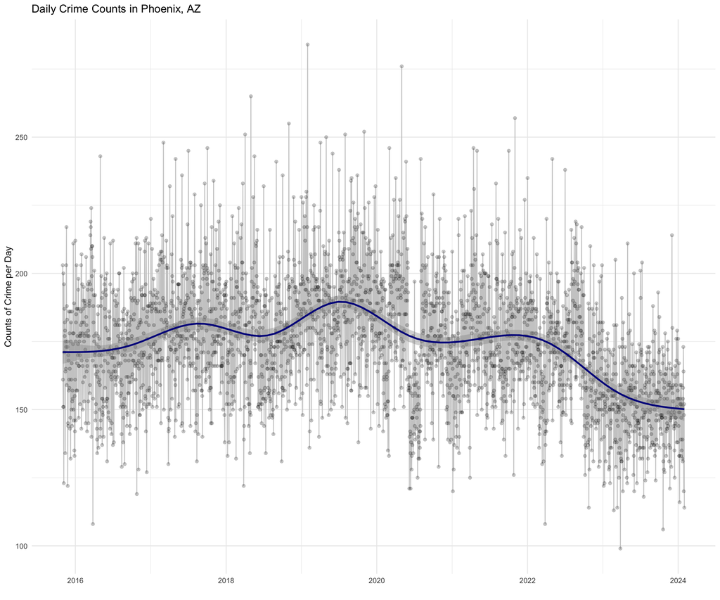

```r
# plot for crimes by day
crimes.by.day %>%
  ggplot( aes( days, counts ) ) +
  geom_line( color = "grey80" ) +
  geom_point( alpha = 1/5, color = "black" ) +
  labs( x = "", y = "Counts of Crime per Day" ) +
  ggtitle( "Daily Crime Counts in Phoenix, AZ" ) +
  geom_smooth( color = "darkblue", span = 0.2 ) +
  scale_y_continuous( label = comma ) +
  theme_minimal()
```

The plot shows a fairly stable daily count of crimes. *But*, a marked **decline** towards the end of 2019. Since the end of 2019 through the beginning of 2024, crime incidents have been trending down in Phoenix.

For a more in-depth examination of crime in 2020 and how it differed from 2019, check out this [analysis](https://jacobtnyoung.github.io/R2PhX/projects/PHXcrime_types_2020.html).

Importantly, since the end of 2019, there has been an overall decrease in the daily counts of crime incidents. Since the beginning of 2022, there has been a *consistent and sizable decrease in crime incidents*.

# What about rates?

## Rates of crime

The daily count view is useful, but it might help if we make two changes:

- First, we should break it down by year and month. This adjustment corrects for the seasonality of crime. One way to show this seasonal variation in crime incidents is to plot the monthly incidents for each year. Note that for 2024, the line stops the month before February, as that is the last month of complete data from the portal.
- Second, we should adjust the counts to be *rates* of incidents of crime. This will adjust for differences in the population of Phoenix from 2016-2024. The crime incident rate is calculated as the count of crimes divided by the population size, then multiplied by 100,000. This then tells us how many incidents of crime occur per 100,000 people in the population.

### Creating rates

The rates are compuated using population data from the [Census Bureau](https://www.census.gov/topics/population.html). The site lists Excel files with estimates of population for incorporated places. Since this is an .xlxs file, we will use the `openxlxs` package (again, click the “Show” button on the right to see the code for this section).

We will work with two files:

- Years 2010-2019 for [Arizona](https://www2.census.gov/programs-surveys/popest/tables/2010-2019/cities/totals/SUB-IP-EST2019-ANNRES-04.xlsx)
- Years 2020-2021 for [Arizona](https://www2.census.gov/programs-surveys/popest/tables/2020-2021/cities/totals/SUB-IP-EST2021-POP-04.xlsx)

Let’s pull these estimates in and get the data for Phoenix.

```r
# ---------------------------
# Population data for Phoenix

# load the openxlsx package
library( openxlsx )

# There are multiple files needed for the population data

# get years 2016-2019
pop.data.2016.2019 <- read.xlsx(
  "https://www2.census.gov/programs-surveys/popest/tables/2010-2019/cities/totals/SUB-IP-EST2019-ANNRES-04.xlsx",
  colNames = TRUE,
  startRow = 4
)

# Find the row with the data for Phoenix
grep("Phoenix", pop.data.2016.2019[,1])

# It is the 55th row in the object
phoenix.pop.2016.2019 <-  pop.data.2016.2019[55,]
phoenix.pop.2016.2019

# We only need the data for 2016-2019
phoenix.pop.2016.2019 <- phoenix.pop.2016.2019[-c(1:9)]
phoenix.pop.2016.2019

# Repeat these steps for the 2020-2021 data
pop.data.2020.2021 <- read.xlsx(
  "https://www2.census.gov/programs-surveys/popest/tables/2020-2021/cities/totals/SUB-IP-EST2021-POP-04.xlsx",
  colNames = TRUE,
  startRow = 4
)

grep( "Phoenix", pop.data.2020.2021[,1] )

phoenix.pop.2020.2021 <-  pop.data.2020.2021[55,]
phoenix.pop.2020.2021

phoenix.pop.2020.2021 <- phoenix.pop.2020.2021[-c(1:2)]
phoenix.pop.2020.2021

# combine the data into a single object
phoenix.pop <- cbind( phoenix.pop.2016.2019, phoenix.pop.2020.2021 )
phoenix.pop

# Missing 2022 and 2023 and 2024
# Add the difference for each year until you get the actual demographic data
phoenix.pop$"2022" <- phoenix.pop$"2021" + phoenix.pop$"2021" - phoenix.pop$"2020"
phoenix.pop$"2023" <- phoenix.pop$"2022" + phoenix.pop$"2022" - phoenix.pop$"2021"
phoenix.pop$"2024" <- phoenix.pop$"2023" + phoenix.pop$"2023" - phoenix.pop$"2022"

# now we coerce the data to be numeric to use it below
phoenix.pop.data <- as.numeric( phoenix.pop )
phoenix.pop.data
```

# What about crime by month?

# Reworking the data to monthly incidents

This takes some reworking of the data.

- First, rather than collapsing by day, we want to record counts by month.
- Second, we need to create a `ts()` object. That is, we need to create a time series object using the `ts()` function. We will also use the `ggseasonplot()` from the `forecast` package.

```r
# Use dplyr() to create an object that is the monthly count of crimes
crimes.by.month <-
  crime.data %>%
  select( year, month ) %>%
  filter( year != 2015 ) %>%
  filter( !is.na( year ) ) %>%
  group_by( year, month ) %>%
  summarize( counts = n() ) %>%
  spread( year, counts ) %>%
  arrange( match( month, month.name ) ) %>%
  select( !month )

# Crimes by year
crimes.by.year <-
  crime.data %>%
  select( year ) %>%
  filter( year != 2015 ) %>%
  filter( !is.na( year ) ) %>%
  group_by( year ) %>%
  summarize( counts = n() )


# ------------------------------------------
# Create the rates using the population data

# now, calculate the crime rate
# Crime rate is calculated as the count of
# crimes divided by the population size, then multiplied by 100,000

crime.rates <- as.data.frame( crimes.by.month )

for ( i in 1: dim( crime.rates )[2] ){
  crime.rates[,i] <- ( crime.rates[,i] / phoenix.pop.data[i] ) * 100000
}

# calculate the crime rate by year
crime.rates.year <- as.data.frame( crimes.by.year )

for ( i in 1: dim( crime.rates.year )[1] ){
  crime.rates.year[i,2] <- ( crime.rates.year[i,2] / phoenix.pop.data[i] ) * 100000
}

# rename the counts column to be rates
crime.rates.year <- crime.rates.year %>%  rename( rates = counts )



# Now, lets use the ts() function to create a time series object.
library( forecast )


# create the time series
monthly.crime.rate.by.year <- ts(
  matrix( as.matrix( crime.rates ), ncol = 1 ),
  start=c( 2016, 1 ),
  end=c( as.numeric( tail( names( crime.rates ), n=1 ) ), 12 ), frequency=12
)
```

## Seasonality

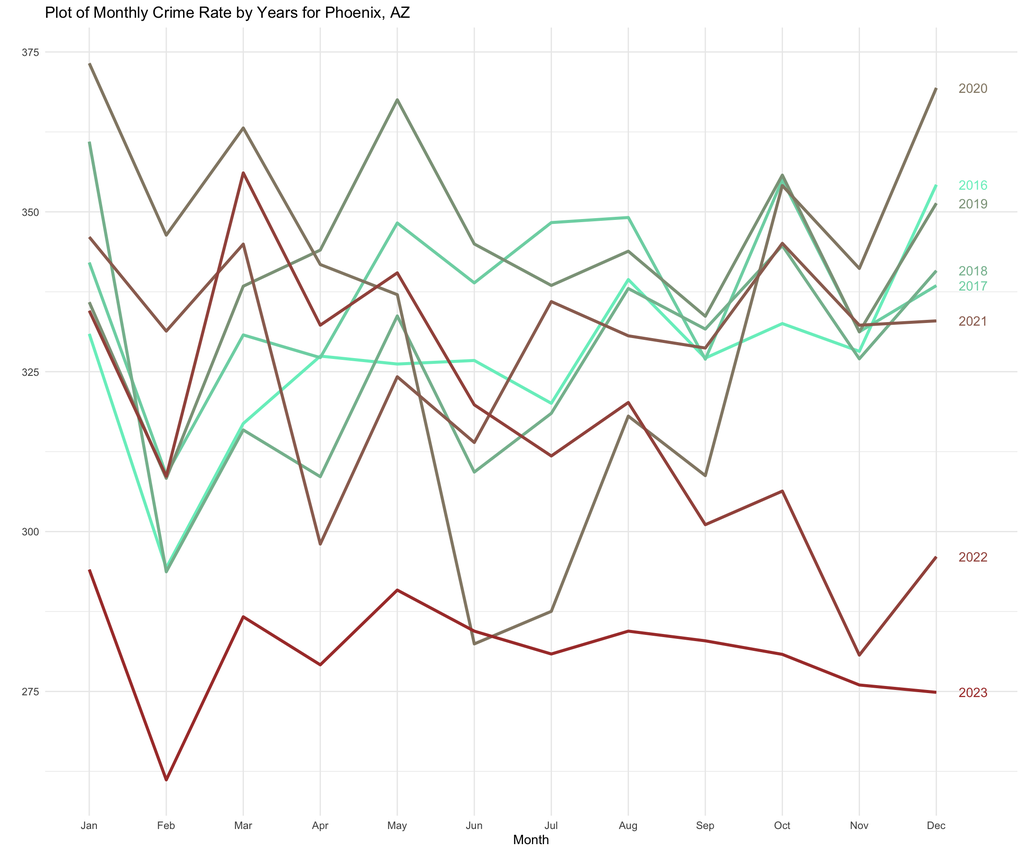

```r
library( ggplot2 )

monthly.crime.rate.by.year %>%
  ggseasonplot(
    year.labels = TRUE,
    continuous = FALSE,
    main = "Plot of Monthly Crime Rate by Years for Phoenix, AZ",
    col = colorRampPalette(c("aquamarine2", "firebrick"))( dim( crime.rates )[2] ) ) +
  scale_y_continuous( label = comma ) +
  geom_line( size = 1.2 ) +
  theme_minimal()
```

The plot showing the monthly rates by year helps us visualize the data better. Note that the current year, 2024, is missing a label because the year is incomplete. There are a few important patterns we can take from the plot:

- First, the trend for 2020 is *unusual* relative to other years. *Particularly* for the period of March-June. For a more elaborate discussion of this trend, see this [analysis](https://jacobtnyoung.github.io/R2PhX/projects/PHXcrime_types_2020.html).
- Second, relative to past years, more recent criminal incidents tend to be lower. For example, 2022 and 2023 both show a generally lower rate of crime incidents relative to 2017-2021.
- Third, there has been a considerable decline in crime incidents toward the end of 2022 that continued through 2023.

# What about crime by year?

## Seasonality

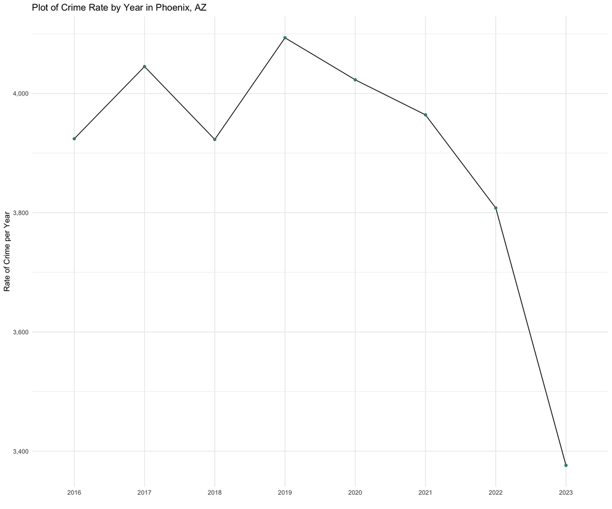

```r
library( ggplot2 )


crime.rates.year %>%
  # drop the current year because it distorts the graph
  filter( year != as.numeric( format( Sys.Date(), format="%Y" ) ) ) %>%
    ggplot( aes( year, rates, group = 1 ) ) +
    geom_line( color = "black") +
    geom_point( color = "aquamarine4" ) +
    labs( x = "", y = "Rate of Crime per Year" ) +
    ggtitle( "Plot of Crime Rate by Year in Phoenix, AZ" ) +
    scale_y_continuous( label = comma ) +
    theme_minimal()
```

# Next steps…

Note that these plots represents **all** types of crimes. For a more elaborate discussion of various crime types, check out this [analysis](https://jacobtnyoung.github.io/R2PhX/projects/PHXcrime_types.html).

[Back to R 2 Phoenix page](https://jacobtnyoung.github.io/R2PhX/)

*Please* report any needed corrections to the [Issues](https://github.com/jacobtnyoung/R2PhX/issues/new) page. Thanks!

###### *Last updated 14 February, 2024*